# Introduction to Data Science HW 4

##### Copyright Jeffrey Stanton, Jeffrey Saltz, and Jasmina Tacheva

```r
# Enter your name here: Patrick Walsh
```

### Attribution statement: (choose only one and delete the rest)

```r
# 1. I did this homework by myself, with help from the book and the professor.
```

Reminders of things to practice from previous weeks:  
Descriptive statistics: mean( ) max( ) min( )  
Coerce to numeric: as.numeric( )

## Part 1: Use the Starter Code

Below, I have provided a starter file to help you.

Each of these lines of code **must be commented** (the comment must that explains what is going on, so that I know you understand the code and results).

```r
library(jsonlite)  # load the jsonlite library
dataset <- url("https://intro-datascience.s3.us-east-2.amazonaws.com/role.json")  # retrieve this JSON dataset from the URL and save it to variable called 'dataset'
readlines <- jsonlite::fromJSON(dataset)  # converts JSON object to R object
df <- readlines$objects$person  # saves readlines objects as a dataframe called 'df'
```

1. Explore the **df** dataframe (e.g., using head() or whatever you think is best).

```r
library(tidyverse)
glimpse(df)
```

```
## Rows: 100
## Columns: 17
## $ bioguideid   <chr> "C000880", "G000386", "L000174", "M001153", "M001111", "S…
## $ birthday     <chr> "1951-05-20", "1933-09-17", "1940-03-31", "1957-05-22", "…
## $ cspanid      <int> 26440, 1167, 1552, 1004138, 25277, 5929, 1859, 1962, 4546…
## $ firstname    <chr> "Michael", "Charles", "Patrick", "Lisa", "Patty", "Charle…
## $ gender       <chr> "male", "male", "male", "female", "female", "male", "male…
## $ gender_label <chr> "Male", "Male", "Male", "Female", "Female", "Male", "Male…
## $ lastname     <chr> "Crapo", "Grassley", "Leahy", "Murkowski", "Murray", "Sch…
## $ link         <chr> "https://www.govtrack.us/congress/members/michael_crapo/3…
## $ middlename   <chr> "D.", "E.", "J.", "A.", "", "E.", "C.", "", "", "", "M.",…
## $ name         <chr> "Sen. Michael “Mike” Crapo [R-ID]", "Sen. Charles “Chuck”…
## $ namemod      <chr> "", "", "", "", "", "", "", "", "", "", "", "", "", "", "…
## $ nickname     <chr> "Mike", "Chuck", "", "", "", "Chuck", "", "", "", "", "",…
## $ osid         <chr> "N00006267", "N00001758", "N00009918", "N00026050", "N000…
## $ pvsid        <chr> "26830", "53293", "53353", "15841", "53358", "26976", "53…
## $ sortname     <chr> "Crapo, Michael “Mike” (Sen.) [R-ID]", "Grassley, Charles…
## $ twitterid    <chr> "MikeCrapo", "ChuckGrassley", "SenatorLeahy", "LisaMurkow…
## $ youtubeid    <chr> "senatorcrapo", "senchuckgrassley", "SenatorPatrickLeahy"…
```

2. Explain the dataset  
   o What is the dataset about?  
   o How many rows are there and what does a row represent?  
   o How many columns and what does each column represent?

```r
# The dataset contains data about U.S. senators. There are 100 senators at any given time serving in the U.S. Senate.
# There are 100 rows and each row represents a different senator.
# There are 17 columns and each column represents an attribute or feature of that senator, such as their name, gender, website, and twitter id.
```

C. What does running this line of code do? Explain in a comment:

```r
# Uses the substr() function which extracts a portion of the birthday column from the df dataframe and saves it
# to a variable called 'vals'. It slices out the first 4 characters only, giving us the year of the birtdate.
vals <- substr(df$birthday,1,4)
vals
```

```
##   [1] "1951" "1933" "1940" "1957" "1950" "1950" "1934" "1949" "1950" "1950"
##  [11] "1955" "1954" "1955" "1961" "1959" "1961" "1964" "1972" "1968" "1965"
##  [21] "1946" "1971" "1963" "1957" "1971" "1955" "1972" "1968" "1951" "1958"
##  [31] "1964" "1958" "1947" "1933" "1950" "1962" "1952" "1952" "1943" "1954"
##  [41] "1941" "1951" "1973" "1947" "1966" "1960" "1956" "1960" "1955" "1952"
##  [51] "1971" "1947" "1976" "1949" "1944" "1961" "1951" "1970" "1958" "1957"
##  [61] "1952" "1954" "1979" "1947" "1964" "1952" "1952" "1944" "1955" "1934"
##  [71] "1942" "1956" "1949" "1943" "1947" "1954" "1963" "1953" "1957" "1972"
##  [81] "1946" "1958" "1977" "1962" "1969" "1964" "1970" "1960" "1954" "1972"
##  [91] "1960" "1958" "1959" "1954" "1954" "1952" "1959" "1973" "1987" "1969"
```

D. Create a new attribute ‘age’ - how old the person is **Hint:** You may need to convert it to numeric first.

```r
# I am using the eeptools library to accomplish this task. I first grab today's date using the Sys.Date()
# function and calculate the age of the senators by using the age_calc() function using today's date and
# the birthdate, displaying the output in years.


library("eeptools")  # load library into RStudio
date_today <-  Sys.Date()  # get today's date
date_today
```

```
## [1] "2022-11-05"
```

```r
birthdate <- as.Date(df$birthday)  # save vector of birthdates from dataframe to variable called 'birthdate'
birthdate
```

```
##   [1] "1951-05-20" "1933-09-17" "1940-03-31" "1957-05-22" "1950-10-11"
##   [6] "1950-11-23" "1934-05-06" "1949-05-03" "1950-01-10" "1950-12-10"
##  [11] "1955-11-30" "1954-05-29" "1955-12-19" "1961-11-17" "1959-01-10"
##  [16] "1961-01-07" "1964-11-28" "1972-08-24" "1968-03-04" "1965-09-19"
##  [21] "1946-02-13" "1971-05-28" "1963-01-07" "1957-03-13" "1971-06-04"
##  [26] "1955-04-08" "1972-10-20" "1968-03-12" "1951-11-21" "1958-02-27"
##  [31] "1964-03-29" "1958-10-13" "1947-01-23" "1933-06-22" "1950-04-29"
##  [36] "1962-02-11" "1952-06-06" "1952-11-09" "1943-10-05" "1954-01-01"
##  [41] "1941-09-08" "1951-07-05" "1973-08-03" "1947-11-03" "1966-12-09"
##  [46] "1960-05-25" "1956-08-21" "1960-04-13" "1955-10-20" "1952-07-21"
##  [51] "1971-10-17" "1947-08-24" "1976-07-12" "1949-06-22" "1944-03-31"
##  [56] "1961-01-21" "1951-03-01" "1970-12-22" "1958-02-26" "1957-08-02"
##  [61] "1952-12-01" "1954-03-24" "1979-12-31" "1947-03-12" "1964-02-21"
##  [66] "1952-12-07" "1952-02-02" "1944-11-21" "1955-07-09" "1934-11-17"
##  [71] "1942-02-20" "1956-10-24" "1949-11-12" "1943-05-03" "1947-01-28"
##  [76] "1954-12-15" "1963-09-09" "1953-11-26" "1957-09-28" "1972-06-07"
##  [81] "1946-07-11" "1958-12-01" "1977-05-13" "1962-08-20" "1969-04-27"
##  [86] "1964-11-13" "1970-07-01" "1960-08-30" "1954-10-24" "1972-02-22"
##  [91] "1960-08-09" "1958-03-04" "1959-05-10" "1954-09-10" "1954-09-18"
##  [96] "1952-02-07" "1959-08-14" "1973-03-22" "1987-02-16" "1969-07-23"
```

```r
age <- age_calc(birthdate, date_today, unit="years")  # saves vector of ages to variable called 'age'
age
```

```
##   [1] 71.46301 89.13425 82.60000 65.45753 72.06849 71.95068 88.50137 73.50959
##   [9] 72.81918 71.90411 66.93151 68.43836 66.87945 60.96712 63.81918 61.82740
##  [17] 57.93946 50.20000 54.67397 57.12877 76.72603 51.44110 59.82740 65.64932
##  [25] 51.42192 67.57808 50.04384 54.65205 70.95616 64.68767 58.60548 64.06301
##  [33] 75.78356 89.37260 72.52055 60.73151 70.41644 69.99138 79.08493 68.84384
##  [41] 81.15890 71.33699 49.25753 75.00548 55.90685 62.44932 66.20822 62.56438
##  [49] 67.04384 70.29315 51.05205 75.20000 46.31781 73.37260 78.60000 61.78904
##  [57] 71.68219 51.87123 64.69041 65.26027 69.93127 68.61918 42.84658 75.65205
##  [65] 58.70411 69.91487 70.75616 77.95859 67.32603 87.96712 80.70685 66.03288
##  [73] 72.98082 79.50959 75.76986 67.89041 59.15616 68.94247 65.10411 50.41370
##  [81] 76.32055 63.92877 45.48219 60.21096 53.52603 57.98045 52.34795 62.18356
##  [89] 68.03288 50.70137 62.24110 64.67397 63.49041 68.15342 68.13151 70.74247
##  [97] 63.22740 49.62466 35.71781 53.28767
```

E. Create a function that reads in the role json dataset, and adds the age attribute to the dataframe, and returns that dataframe

```r
add_age <- function(age){
  df$age = age  # add a vector to the dataframe
  return(df)
}
```

F. Use (call, invoke) the function, and store the results in df

```r
df <- add_age(age)
glimpse(df)
```

```
## Rows: 100
## Columns: 18
## $ bioguideid   <chr> "C000880", "G000386", "L000174", "M001153", "M001111", "S…
## $ birthday     <chr> "1951-05-20", "1933-09-17", "1940-03-31", "1957-05-22", "…
## $ cspanid      <int> 26440, 1167, 1552, 1004138, 25277, 5929, 1859, 1962, 4546…
## $ firstname    <chr> "Michael", "Charles", "Patrick", "Lisa", "Patty", "Charle…
## $ gender       <chr> "male", "male", "male", "female", "female", "male", "male…
## $ gender_label <chr> "Male", "Male", "Male", "Female", "Female", "Male", "Male…
## $ lastname     <chr> "Crapo", "Grassley", "Leahy", "Murkowski", "Murray", "Sch…
## $ link         <chr> "https://www.govtrack.us/congress/members/michael_crapo/3…
## $ middlename   <chr> "D.", "E.", "J.", "A.", "", "E.", "C.", "", "", "", "M.",…
## $ name         <chr> "Sen. Michael “Mike” Crapo [R-ID]", "Sen. Charles “Chuck”…
## $ namemod      <chr> "", "", "", "", "", "", "", "", "", "", "", "", "", "", "…
## $ nickname     <chr> "Mike", "Chuck", "", "", "", "Chuck", "", "", "", "", "",…
## $ osid         <chr> "N00006267", "N00001758", "N00009918", "N00026050", "N000…
## $ pvsid        <chr> "26830", "53293", "53353", "15841", "53358", "26976", "53…
## $ sortname     <chr> "Crapo, Michael “Mike” (Sen.) [R-ID]", "Grassley, Charles…
## $ twitterid    <chr> "MikeCrapo", "ChuckGrassley", "SenatorLeahy", "LisaMurkow…
## $ youtubeid    <chr> "senatorcrapo", "senchuckgrassley", "SenatorPatrickLeahy"…
## $ age          <dbl> 71.46301, 89.13425, 82.60000, 65.45753, 72.06849, 71.9506…
```

## Part 2: Investigate the resulting dataframe ‘df’

1. How many senators are women?

```r
length(which(df$gender=="female"))
```

```
## [1] 24
```

2. How many senators have a YouTube account?

```r
length(which(!is.na(df$youtubeid)))
```

```
## [1] 73
```

3. How many women senators have a YouTube account?

```r
nrow(df %>% filter(gender == "female", !is.na(youtubeid)))
```

```
## [1] 16
```

4. Create a new dataframe called **youtubeWomen** that only includes women senators who have a YouTube account.

```r
youtubewomen <- df %>% filter(gender == "female", !is.na(youtubeid))
glimpse(youtubewomen)
```

```
## Rows: 16
## Columns: 18
## $ bioguideid   <chr> "M001153", "M001111", "D000622", "C000127", "F000062", "S…
## $ birthday     <chr> "1957-05-22", "1950-10-11", "1968-03-12", "1958-10-13", "…
## $ cspanid      <int> 1004138, 25277, 94484, 26137, 13061, 45451, 57884, 31226,…
## $ firstname    <chr> "Lisa", "Patty", "Tammy", "Maria", "Dianne", "Debbie", "T…
## $ gender       <chr> "female", "female", "female", "female", "female", "female…
## $ gender_label <chr> "Female", "Female", "Female", "Female", "Female", "Female…
## $ lastname     <chr> "Murkowski", "Murray", "Duckworth", "Cantwell", "Feinstei…
## $ link         <chr> "https://www.govtrack.us/congress/members/lisa_murkowski/…
## $ middlename   <chr> "A.", "", "", "", "", "Ann", "", "W.", "K.", "E.", "Jean"…
## $ name         <chr> "Sen. Lisa Murkowski [R-AK]", "Sen. Patty Murray [D-WA]",…
## $ namemod      <chr> "", "", "", "", "", "", "", "", "", "", "", "", "", "", "…
## $ nickname     <chr> "", "", "", "", "", "", "", "", "", "", "", "", "", "", "…
## $ osid         <chr> "N00026050", "N00007876", "N00027860", "N00007836", "N000…
## $ pvsid        <chr> "15841", "53358", "57442", "27122", "53273", "515", "3470…
## $ sortname     <chr> "Murkowski, Lisa (Sen.) [R-AK]", "Murray, Patty (Sen.) [D…
## $ twitterid    <chr> "LisaMurkowski", "PattyMurray", "SenDuckworth", "SenatorC…
## $ youtubeid    <chr> "senatormurkowski", "SenatorPattyMurray", "repduckworth",…
## $ age          <dbl> 65.45753, 72.06849, 54.65205, 64.06301, 89.37260, 72.5205…
```

5. Make a histogram of the **age** of senators in **youtubeWomen**, and then another for the senators in **df**. Add a comment describing the shape of the distributions.

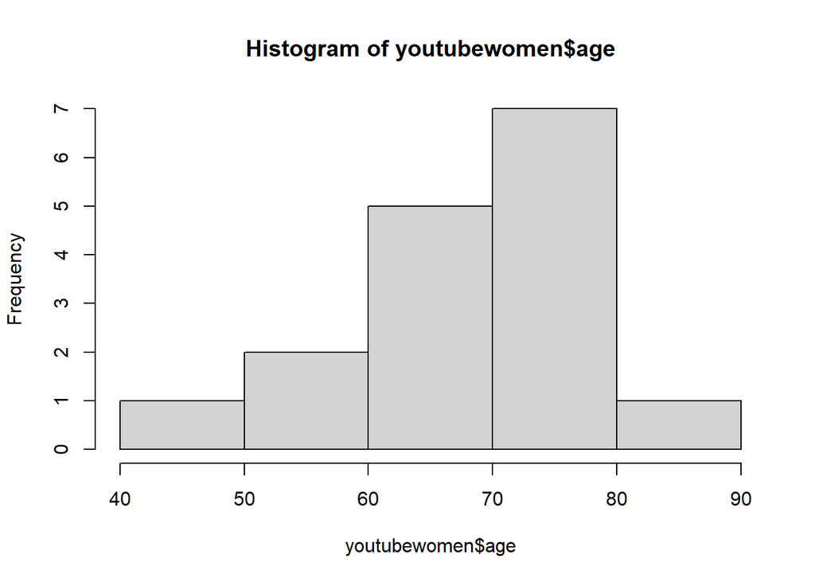

```r
hist(youtubewomen$age)
```

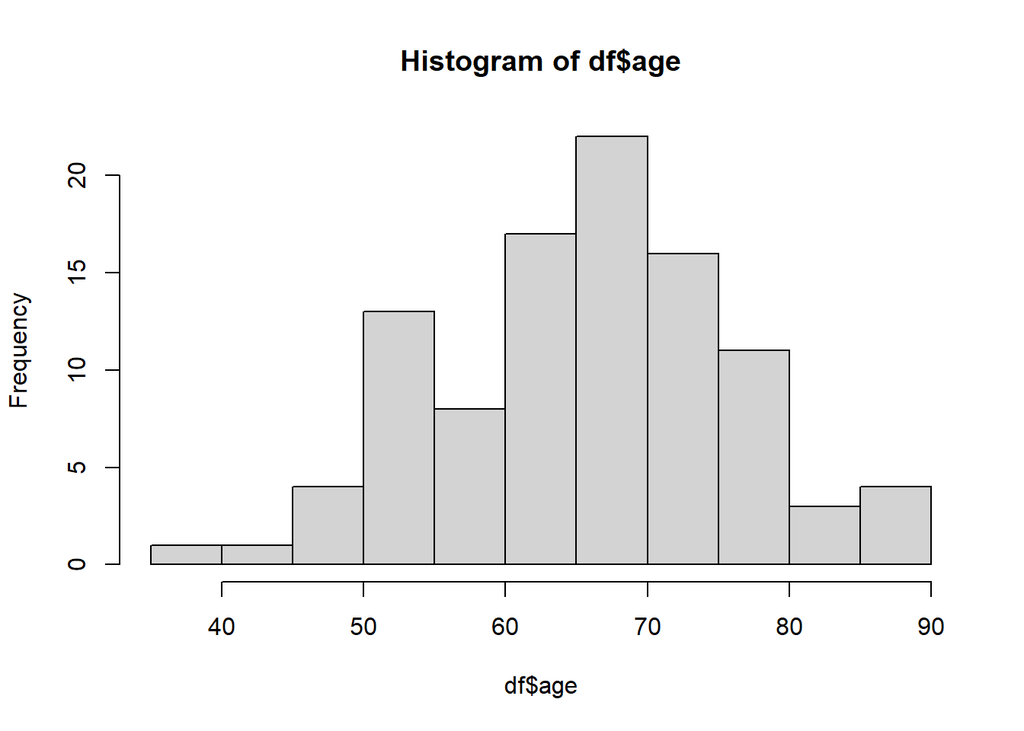

```r
hist(df$age)
```

```r
# The youtubewomen$age histogram is left-skewed whereas the df$age histogram is fairly normally distrubuted.
# This means that the mean and mode in df$age histogram are close to the same, while in the the youtubewomen$age
# histogram, the mean is to the left of the mode.
```